# Homework #10

Natalia Aristizábal

10/31/2018

1. “Using a for loop, write a function to calculate the number of zeroes in a numeric vector. Before entering the loop, set up a counter variable counter <- 0. Inside the loop, add 1 to counter each time you have a zero in the matrix. Finally, use return(counter) for the output.”

```r
# libraries
library(dplyr)
vec<-rbinom(20, 1, 0.5)

count <- function(a=vec){
  counter <- 0
  for(i in seq_along(a)){
    if(a[i]==0) counter <- counter + 1
  }
   return(counter)
}

count()
```

```
## [1] 7
```

2. “Use subsetting instead of a loop to rewrite the function as a single line of code.”

```r
x=rbinom(20, 1, 0.5)

count_zeroes <- function(a=x) {
  zeros <- length(a[a==0])
  return(zeros)
}

count_zeroes()
```

```
## [1] 15
```

3. “Write a function that takes as input two integers representing the number of rows and columns in a matrix. The output is a matrix of these dimensions in which each element is the product of the row number x the column number.”

```r
# FUNCTION: making a matrix
# INPUTS: two integers representing the number of rows and columns in a matrix
# OUTPUTS: matrix of these dimensions in which each element is the product of the row number x the column number.

mat_fun <- function(numbrows=7, numbcols=9){
  m <- matrix(nrow = numbrows, ncol = numbcols)
  for(i in 1:nrow(m)) {
  for(j in 1:ncol(m)) {
    m[i,j] <-  i * j
  }
}
    return(m)
}

mat_fun()
```

```
##      [,1] [,2] [,3] [,4] [,5] [,6] [,7] [,8] [,9]
## [1,]    1    2    3    4    5    6    7    8    9
## [2,]    2    4    6    8   10   12   14   16   18
## [3,]    3    6    9   12   15   18   21   24   27
## [4,]    4    8   12   16   20   24   28   32   36
## [5,]    5   10   15   20   25   30   35   40   45
## [6,]    6   12   18   24   30   36   42   48   54
## [7,]    7   14   21   28   35   42   49   56   63
```

4. “Use the code from yesterday’s class to design and conduct a randomization test for some of your own data. You will need to modify the functions that read in the data, calculate the metric, and randomize the data. Once those are set up, the program should run correctly calling your new functions. Also, to make your analysis fully repeatable, make sure you set the random number seed at the beginning (use either set.seed() in base R, or char2seed in the TeachingDemos package.”

```r
library(ggplot2)
library(TeachingDemos)
set.seed(1000)

# random data from previous homework
x <- rnorm(n=100,mean=10,sd=2)
noise <- rnorm(n=100, sd=10)
y <- 5.5 + x*10 + noise

# function readData
readData <- function(z=NULL){
  if(is.null(z)){
    xObs <- x
    yObs <- y
    dF <- data.frame(ID=seq_along(xObs),
                     xObs,
                     yObs)} else {
                       dF <- read.table(file=z,
                                        row.names = 1,
                                        header=TRUE,
                                        sep=",",
                                        stringsAsFactors = FALSE)}
  return(dF)
}

readData()
```

```
##      ID      xObs      yObs
## 1     1  9.108443  82.89031
## 2     2  7.588287  83.01304
## 3     3 10.082253 105.19026
## 4     4 11.278777 126.88532
## 5     5  8.426891  91.05557
## 6     6  9.229021  99.71993
## 7     7  9.048264  99.87921
## 8     8 11.439501  97.61960
## 9     9  9.962989 115.39723
## 10   10  7.253764  90.07215
## 11   11  8.035144  93.35637
## 12   12  8.891023  91.51703
## 13   13 10.242762 105.65298
## 14   14  9.758255 101.77809
```

[output cut: 86 more lines]

```r
# function to calculate the metric
getMetric <- function(z=NULL){
  if(is.null(z)){
    xObs <- x
    yObs <- y
    z <- data.frame(ID=seq_along(xObs),
                    xObs,
                    yObs)}
  . <- lm(z[,3]~z[,2])
  . <- summary(.)
  . <- .$coefficients[2,4]
  slope <- .
  return(slope)
}

getMetric()
```

```
## [1] 6.68721e-39
```

```r
# create the randomization
shuffleData <- function(z=NULL){
  if(is.null(z)){
    xObs <- x
    yObs <- y
    z <- data.frame(ID=seq_along(xObs),
                    xObs,
                    yObs)}
  z[,3] <- sample(z[,3])
  return(z)
}

shuffleData()
```

```
##      ID      xObs      yObs
## 1     1  9.108443 113.29963
## 2     2  7.588287 164.59307
## 3     3 10.082253  84.29357
## 4     4 11.278777  96.55398
## 5     5  8.426891  91.05557
## 6     6  9.229021 111.05265
## 7     7  9.048264  76.76031
## 8     8 11.439501  70.10292
## 9     9  9.962989 126.82997
## 10   10  7.253764 104.14863
## 11   11  8.035144 101.07593
## 12   12  8.891023  97.61960
## 13   13 10.242762  93.24825
## 14   14  9.758255  96.92505
```

[output cut: 86 more lines]

```r
# calculate p value from simulated metrics
p_val <- function(z=NULL){
  if(is.null(z)){
    xObs <- x
    yObs <- y
    z <- data.frame(ID=seq_along(xObs),
                    xObs,
                    yObs)}
  z[,3] <- sample(z[,3])
  . <- lm(z[,3]~z[,2])
  . <- summary(.)
  . <- .$coefficients[2,4]
  pVal <- .
  return(pVal)
}

p_val()
```

```
## [1] 0.5699466
```

```r
# calculate lower and upper quantiles from simulated metrics

getPVal <- function(z=NULL){
    z <- list(xObs=runif(1),xSim=runif(1000))
pLower <- mean(z[[2]] <= z[[1]])
pUpper <- mean(z[[2]] >= z[[1]])
return(c(pLower,pUpper))
}

getPVal()
```

```
## [1] 0.745 0.255
```

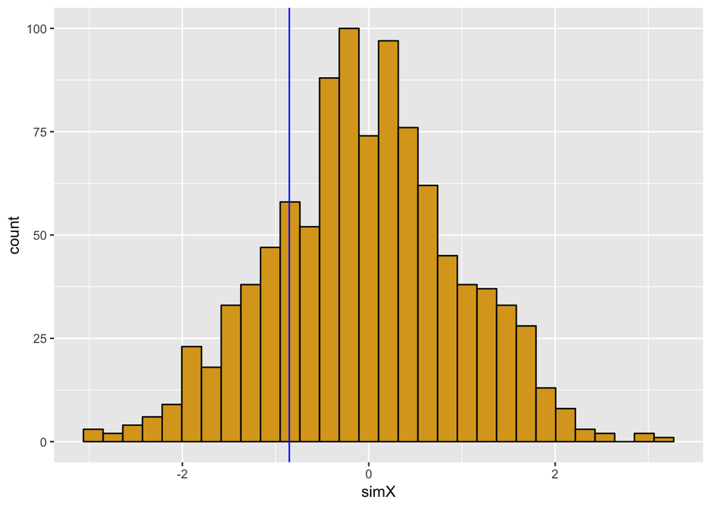

```r
# function: plotRanTest
# create ggplot of histogram of simulated values
# input: list of observed metric and vector of simulated metrics
# output: saved ggplot graph
#-------------------------------------------------
plotRanTest <- function(z=NULL) {
                if(is.null(z)){
                  z <- list(rnorm(1),rnorm(1000)) }
dF <- data.frame(ID=seq_along(z[[2]]),simX=z[[2]])
p1 <- ggplot(data=dF,mapping=aes(x=simX))
p1 + geom_histogram(mapping=aes(fill=I("goldenrod"),color=I("black"))) +
geom_vline(aes(xintercept=z[[1]],col="blue"))

}


plotRanTest()
```

```r
# simulated p values
nSim <- 1000
Xsim <- rep(NA,nSim)
dF <- readData()
Xobs <- getMetric(dF)

for (i in seq_len(nSim)) {
  Xsim[i] <- getMetric(shuffleData(dF))
}

pVals <- list(Xobs,Xsim)
getPVal(z=pVals)
```

```
## [1] 0.962 0.038
```

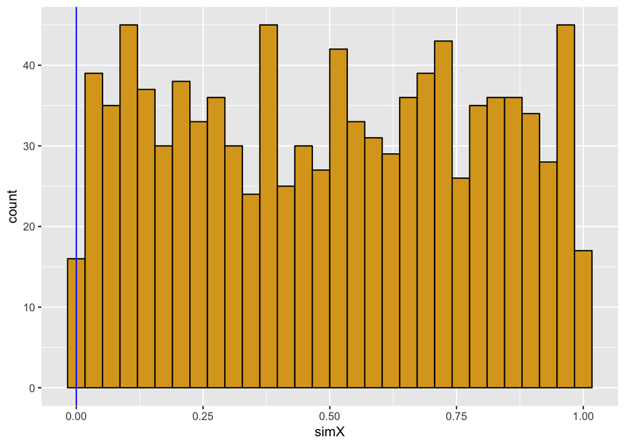

```r
plotRanTest(pVals)
```

5.“For comparison, calculate in R the standard statistical analysis you would use with these data. How does the p-value compare for the standard test versus the p value you estimated from your randomization test? If the p values seem very different, run the program again with a different starting seed (and/or increase the number of replications in your randomization test). If there are persistent differences in the p value of the standard test versus your randomization, what do you think is responsible for this difference?”